# Regression

Julie Josse[^1], Gaël Varoquaux[^2], and Bénédicte Colnet[^3]

Inria

8 Février

Abstract

In this tutorial, you will perform a logistic regression with `R`. This is the first exercice and we will do it together in class. At the end you can find an exercice with a simple linear regression you should be able to do alone at home (solutions will be given in next class).

# Logistic regression application: credit default

The aim is to predict whether a client will have a credit card default from a few simple covariates.

In the ISLR package, there is a dataset Default which measures for 10000 clients 4 variables: - default: a factor variable corresponding to the presence and the absence of default - student: a factor variable having value Yes for a student and No otherwise - balance: the average credit card balance at the end of the month - income : the customer income

## Question 1: load data

Load the Default data set in the package ISLR. Can you describe the data? If you want to predict the credit default, what will be the outcome?

*Solution 1*

```r
library(ISLR)
data(Default)
head(Default)
```

|  | default | student | balance | income |
| --- | --- | --- | --- | --- |
| 1 | No | No | 729.5265 | 44361.625 |
| 2 | No | Yes | 817.1804 | 12106.135 |
| 3 | No | No | 1073.5492 | 31767.139 |
| 4 | No | No | 529.2506 | 35704.494 |
| 5 | No | No | 785.6559 | 38463.496 |
| 6 | No | Yes | 919.5885 | 7491.559 |

10000 observations, 4 columns, the outcome will be default (a binary covariate)

*End of solution 1*

## Question 2: data exploration

Perform typical univariate and bivariate data exploration. Can you already observe a trend?

*Solution 2*

Here you can find several plots with sometimes strange color. It is to show you different parameters to tune and choose your favorite plots. But don’t forget you can find a lot of examples online.

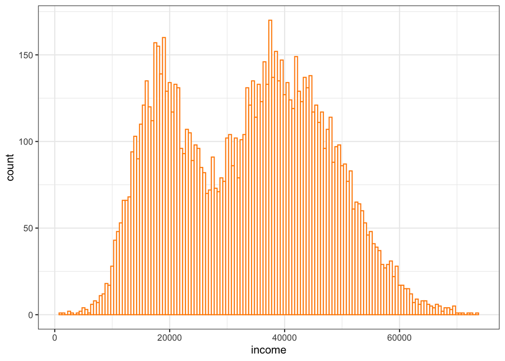

```r
library(ggplot2)
ggplot(Default, aes(x = income)) +
  geom_histogram(binwidth = 500, fill = "white", color = "darkorange") +
  theme_bw()
```

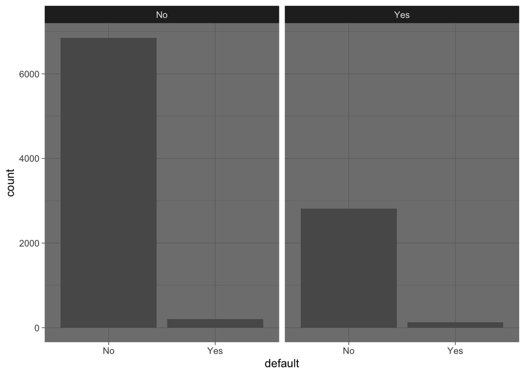

```r
ggplot(Default, aes(x = default)) +
  geom_bar() +
  facet_grid(~student) +
  theme_dark()
```

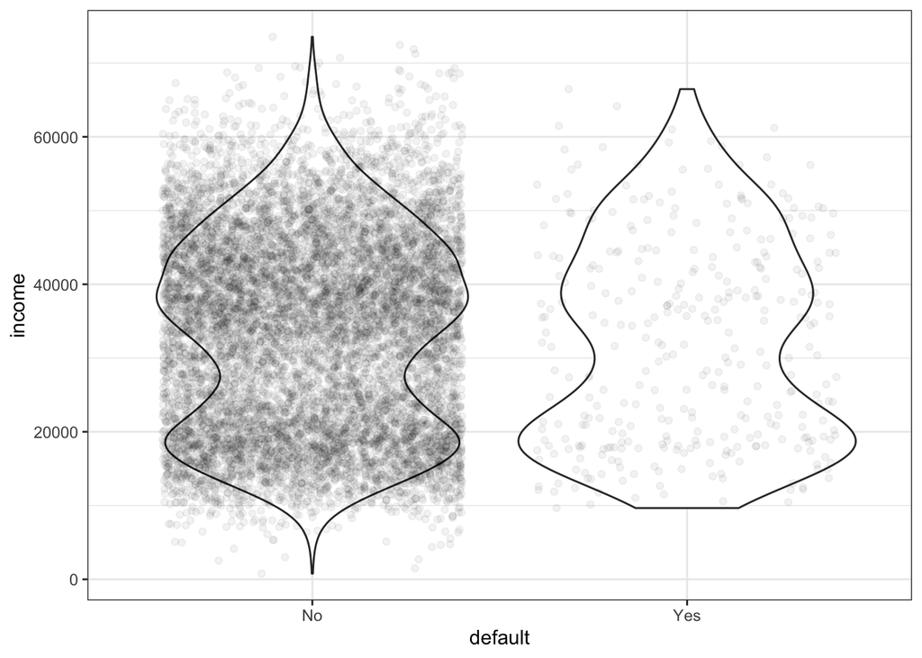

```r
ggplot(Default, aes(x = default, y = income)) +
  geom_violin() +
  theme_bw() +
  geom_jitter(alpha = 0.05)
```

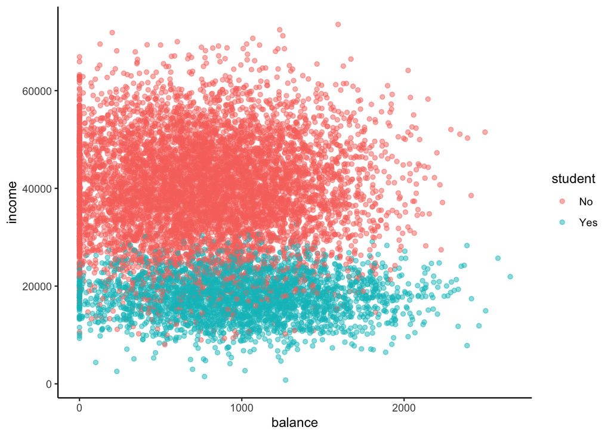

```r
ggplot(Default, aes(x = balance, y = income, color = student)) +
  geom_point(alpha = 0.5) +
  theme_classic()
```

Note that you can also use a package called plotluck:

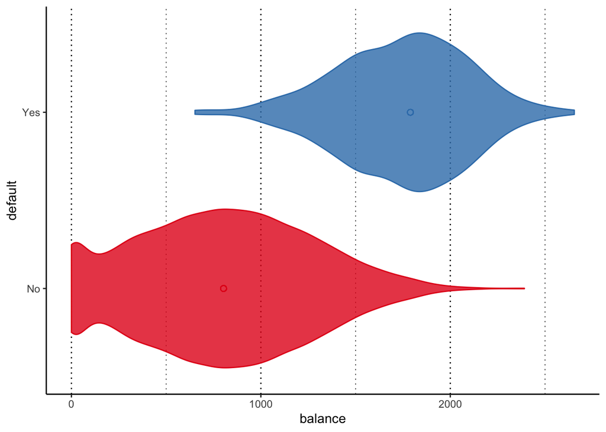

```r
library(plotluck)
plotluck(Default, default ~ balance)
```

*End of solution 2*

## Question 3: compute logistic regression

Compute a logistic regression and interpret it. Does it confirm your first data exploration analysis?

*Solution 3*

```r
Default_logit <- glm(default~ ., family = binomial(link="logit"),
                     data=Default)
summary(Default_logit)
```

```
##
## Call:
## glm(formula = default ~ ., family = binomial(link = "logit"),
##     data = Default)
##
## Deviance Residuals:
##     Min       1Q   Median       3Q      Max
## -2.4691  -0.1418  -0.0557  -0.0203   3.7383
##
## Coefficients:
##               Estimate Std. Error z value Pr(>|z|)
## (Intercept) -1.087e+01  4.923e-01 -22.080  < 2e-16 ***
## studentYes  -6.468e-01  2.363e-01  -2.738  0.00619 **
## balance      5.737e-03  2.319e-04  24.738  < 2e-16 ***
## income       3.033e-06  8.203e-06   0.370  0.71152
## ---
## Signif. codes:  0 '***' 0.001 '**' 0.01 '*' 0.05 '.' 0.1 ' ' 1
##
## (Dispersion parameter for binomial family taken to be 1)
##
##     Null deviance: 2920.6  on 9999  degrees of freedom
## Residual deviance: 1571.5  on 9996  degrees of freedom
## AIC: 1579.5
##
## Number of Fisher Scoring iterations: 8
```

*End of solution 3*

## Question 4: simplify the model

Use the `step` function to simplify the model.

*Solution 4*

```r
# backward selection with AIC
Default_logit_simple <- step(Default_logit,direction="backward")
```

```
## Start:  AIC=1579.54
## default ~ student + balance + income
##
##           Df Deviance    AIC
## - income   1   1571.7 1577.7
## <none>         1571.5 1579.5
## - student  1   1579.0 1585.0
## - balance  1   2907.5 2913.5
##
## Step:  AIC=1577.68
## default ~ student + balance
##
##           Df Deviance    AIC
## <none>         1571.7 1577.7
## - student  1   1596.5 1600.5
## - balance  1   2908.7 2912.7
```

```r
summary(Default_logit_simple)
```

```
##
## Call:
## glm(formula = default ~ student + balance, family = binomial(link = "logit"),
##     data = Default)
##
## Deviance Residuals:
##     Min       1Q   Median       3Q      Max
## -2.4578  -0.1422  -0.0559  -0.0203   3.7435
##
## Coefficients:
##               Estimate Std. Error z value Pr(>|z|)
## (Intercept) -1.075e+01  3.692e-01 -29.116  < 2e-16 ***
## studentYes  -7.149e-01  1.475e-01  -4.846 1.26e-06 ***
## balance      5.738e-03  2.318e-04  24.750  < 2e-16 ***
## ---
## Signif. codes:  0 '***' 0.001 '**' 0.01 '*' 0.05 '.' 0.1 ' ' 1
##
## (Dispersion parameter for binomial family taken to be 1)
##
##     Null deviance: 2920.6  on 9999  degrees of freedom
## Residual deviance: 1571.7  on 9997  degrees of freedom
## AIC: 1577.7
##
## Number of Fisher Scoring iterations: 8
```

*End of solution 4*

## Question 5: accuracy

Compare the two models in term of prediction accuracy. Does it appear to be a good idea to simplify the model?

*Solution 5*

We first predict the outcome with the complete model.

```r
Default_score <- predict(Default_logit, data = Default, type = "response")
```

Same with the simplified one:

```r
Default_simple_score <- predict(Default_logit_simple, data = Default, type = "response")
```

```r
pred <- factor(as.numeric(Default_score>= .5), levels = c(0,1), labels = c("No","Yes"))
pred_simple <- factor(as.numeric(Default_simple_score>= .5), levels = c(0,1), labels = c("No","Yes"))

err = mean(pred != Default$default)
err
```

```
## [1] 0.0268
```

```r
err_simple = mean(pred_simple != Default$default)
err_simple
```

```
## [1] 0.0267
```

*End of solution 5*

# Exploratory Data Analysis and simple regression

## The database

The data are stored in the file ‘bea-2006.csv’. It contains information about the economies of the 366 metropolitan statistical areas" (cities) of the US in 2006. In particular, it lists, for each city:

- the population,
- the total value of all goods and services produced for sale in the city that year per person (per capita gross metropolitan product“, pcgmp),
- and the share of economic output coming from *four* selected industries.

## Question 1: load data

Load the data and perform a summary analysis.

*Solution 1*

```r
data <- read.csv('bea-2006.csv', row.names=1)
```

```r
summary(data)
```

```
##      pcgmp            pop              finance          prof.tech
##  Min.   :14920   Min.   :   54980   Min.   :0.03845   Min.   :0.01474
##  1st Qu.:26532   1st Qu.:  135625   1st Qu.:0.10403   1st Qu.:0.02932
##  Median :31615   Median :  231500   Median :0.14140   Median :0.04212
##  Mean   :32923   Mean   :  680898   Mean   :0.15082   Mean   :0.04905
##  3rd Qu.:38212   3rd Qu.:  530875   3rd Qu.:0.18122   3rd Qu.:0.05932
##  Max.   :77860   Max.   :18850000   Max.   :0.38480   Max.   :0.19080
##                                     NA's   :12        NA's   :112
##       ict            management
##  Min.   :0.00349   Min.   :0.00042
##  1st Qu.:0.01215   1st Qu.:0.00294
##  Median :0.02218   Median :0.00651
##  Mean   :0.03910   Mean   :0.00908
##  3rd Qu.:0.04072   3rd Qu.:0.01191
##  Max.   :0.58600   Max.   :0.05431
##  NA's   :76        NA's   :157
```

*End of solution 1*

## Question 2: data exploration

Produce histogram of population (density and the histogram with “bar”) and the box plot of the pgmp column.

Tips: Don’t hesitate to do an histogram without the outliers.

*Solution 2*

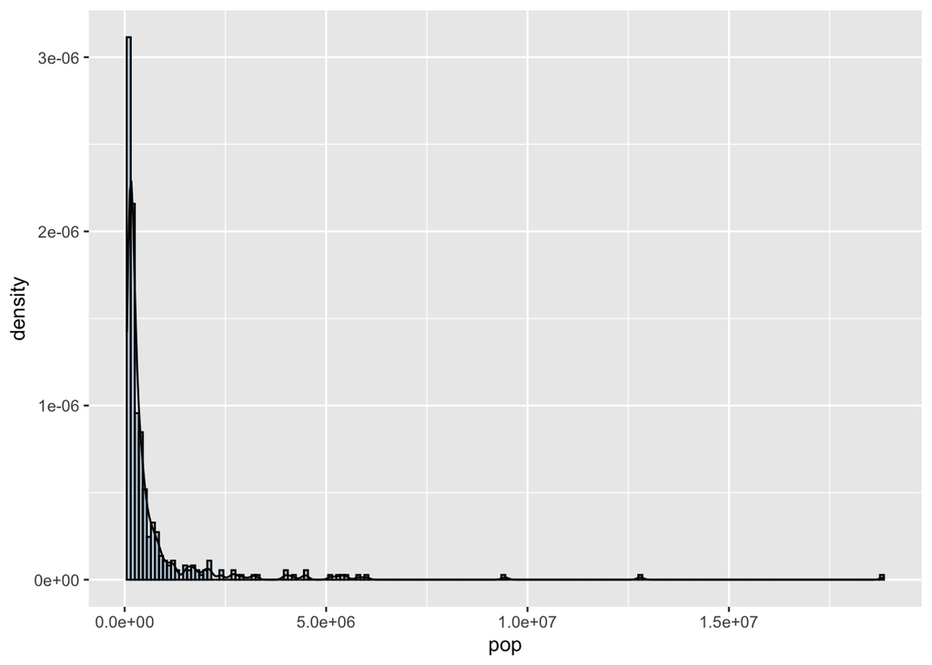

```r
library(ggplot2)
ggplot(data, aes(x = pop)) +
 geom_histogram(aes(y=..density..), alpha=0.3,
                position="identity", binwidth = 100000, fill = "steelblue", color = "black")+
 geom_density(alpha=0.9)
```

```r
  theme_bw()
```

[output not shown]

[output cut: 388 more lines]

[output not shown]

Note that with this plot we can see that outliers seem to be present. You can always use a boxplot to have evidence of it.

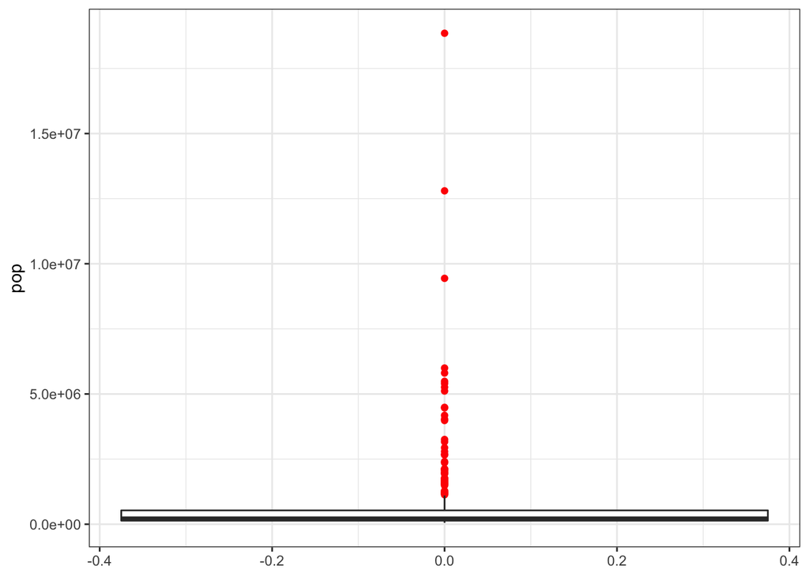

```r
ggplot(data, aes(y = pop)) +
  geom_boxplot(outlier.colour = "red") +
  theme_bw()
```

You can then reproduce the previous plot without the outliers:

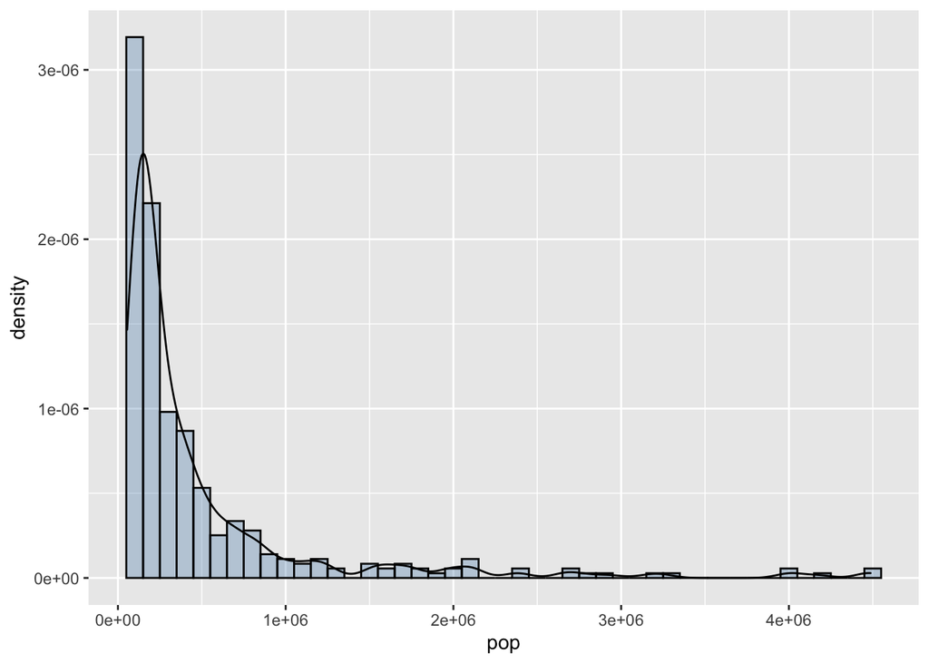

```r
ggplot(data[data$pop < 5000000 ,], aes(x = pop)) +
 geom_histogram(aes(y=..density..), alpha=0.3,
                position="identity", binwidth = 100000, fill = "steelblue", color = "black")+
 geom_density(alpha=0.9)
```

```r
  theme_bw()
```

[output not shown]

[output cut: 388 more lines]

[output not shown]

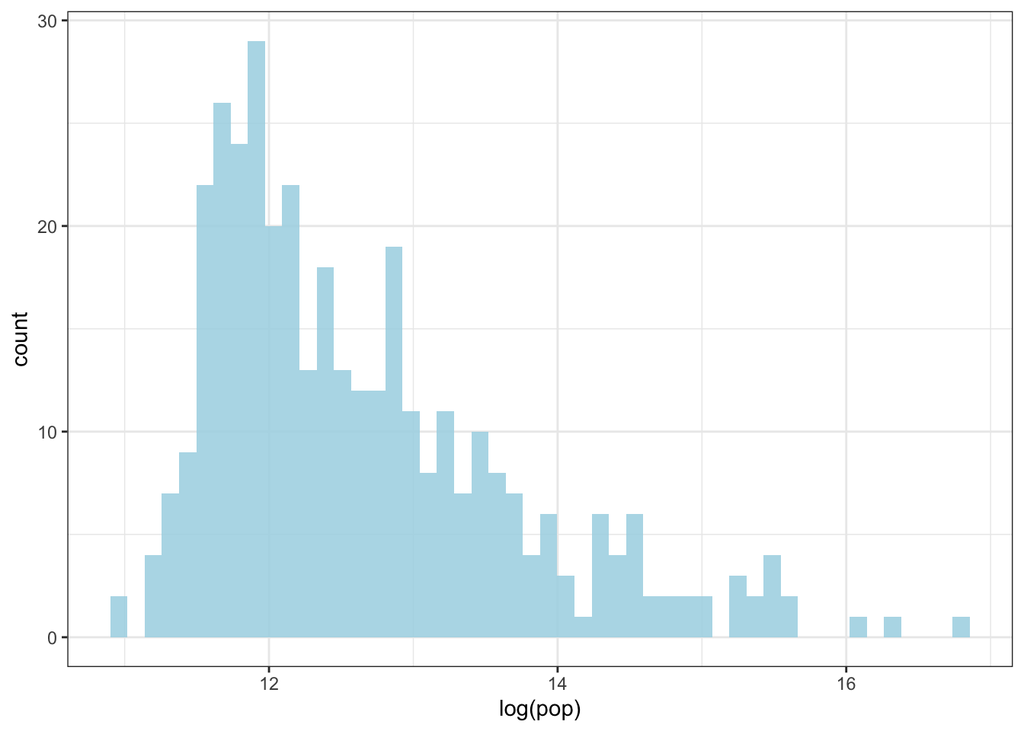

```r
ggplot(data, aes(x = log(pop))) +
  geom_histogram(bins = 50, alpha = 0.9, fill = "lightblue") +
  theme_bw()
```

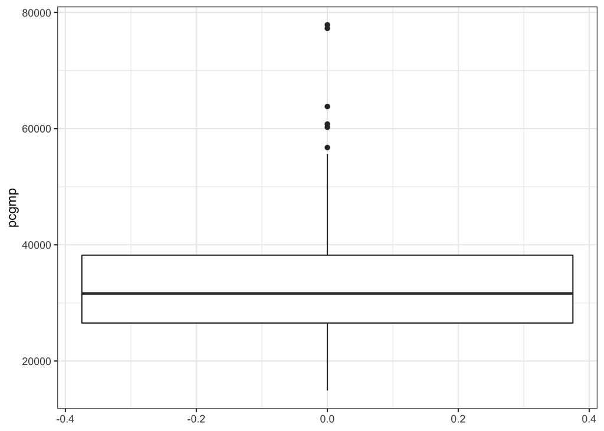

```r
ggplot(data, aes(y = pcgmp)) +
  geom_boxplot() +
  theme_bw()
```

*End of solution 2*

## Question 3: GMP and population

Make a bivariate plot for per-capita GMP as a function of population. Describe the relationship in words. You can also try with $log(pop)$.

*Solution 3*

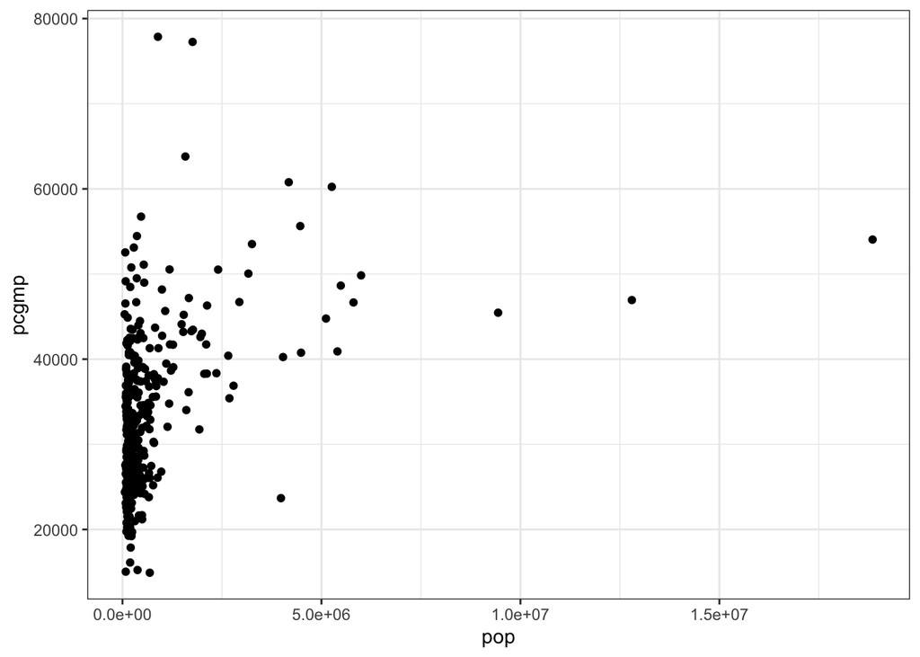

```r
ggplot(data, aes(x = pop, y = pcgmp)) +
  geom_point() +
  theme_bw()
```

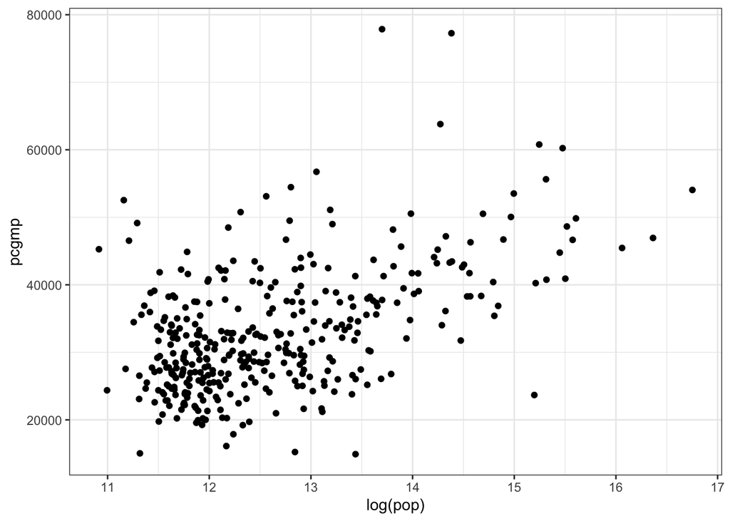

```r
ggplot(data, aes(x = log(pop), y = pcgmp)) +
  geom_point() +
  theme_bw()
```

*End of solution 3*

## Question 4: simple linear model

Considering your previous plot, run the `lm()` function on the data and add the regression to the previous plot. Will you use `pop` or `log(pop)`? (would the last one still be a linear model?)

You can comment the result.

*Solution 4*

```r
model = lm(pcgmp~log(pop), data = data)
print(model$coefficients)
```

```
## (Intercept)    log(pop)
##  -23306.199    4449.758
```

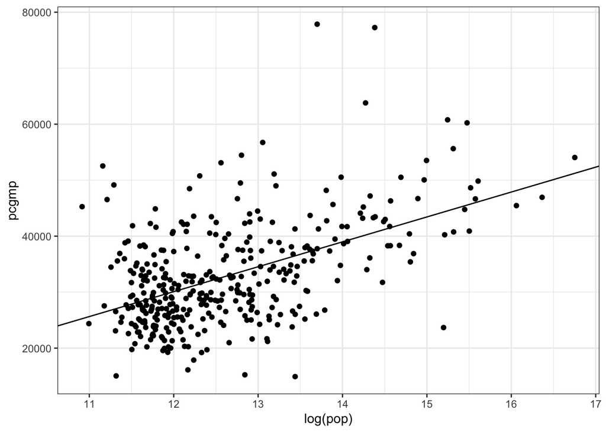

```r
ggplot(data, aes(x = log(pop), y = pcgmp)) +
  geom_point() +
  theme_bw() +
  geom_abline(slope = model$coefficients[[2]], intercept = model$coefficients[[1]])
```

The fit does not seem to be a good one.

```r
summary(model)
```

```
##
## Call:
## lm(formula = pcgmp ~ log(pop), data = data)
##
## Residuals:
##    Min     1Q Median     3Q    Max
## -21572  -4765  -1016   3686  40207
##
## Coefficients:
##             Estimate Std. Error t value Pr(>|t|)
## (Intercept) -23306.2     4957.1  -4.702 3.67e-06 ***
## log(pop)      4449.8      390.9  11.383  < 2e-16 ***
## ---
## Signif. codes:  0 '***' 0.001 '**' 0.01 '*' 0.05 '.' 0.1 ' ' 1
##
## Residual standard error: 7929 on 364 degrees of freedom
## Multiple R-squared:  0.2625, Adjusted R-squared:  0.2605
## F-statistic: 129.6 on 1 and 364 DF,  p-value: < 2.2e-16
```

Note that it is not easy to interpret `log(pop)` in comparison with `pop`.

*End of solution 4*

## Question 5

Bonus question: could you do `log(pcgmp)` as a linear function of `pop` (or `log(pop)`)?

*Solution 5* This would be wrong! Because it implies a multiplication. Here to keep the model linear it should be $log(Y) = \beta X *\varepsilon$ *End of solution 5*

[^1]: Inria Montpellier
[^2]: Inria Paris-Saclay
[^3]: Inria Paris-Saclay